# Introduction to Programming Lecture 11

- Instructor : Andrew Yarmola andrew.yarmola@uni.lu
- Course Schedule : Wednesday 14h00 - 15h30 Campus Kirchberg B21
- Course Website : sites.google.com/site/andrewyarmola/itp-uni-lux
- Office Hours : Thursday 16h00 - 17h00 Campus Kirchberg G103 and by appointment.

# No class Wed Dec 7

### Slicing and views

One can **slice** arrays in a very similar manner to python lists by using

`A[start_0 : end_0 : step_0, start_1 : end_1, step_1, ... ]`.

[figure not shown]

For example :

```python
import numpy as np

a = np.arange(4*4).reshape(4,4)
print(repr(a))
# just like with lists, we don't
# need to include start, end, or step
b = a[0:2,2:]
print(repr(b))
```

```
array([[ 0,  1,  2,  3],
       [ 4,  5,  6,  7],
       [ 8,  9, 10, 11],
       [12, 13, 14, 15]])
array([[2, 3],
       [6, 7]])
```

```python
b = a[::2,::3]
print(repr(b))
```

```
array([[ 0,  3],
       [ 8, 11]])
```

**Important :** The arrays returned by a slice are **views** into the **data of the original**. Thus, if you **modify the data in a view you modify the original data!**

```python
b[0,0] = 17
print(repr(b))
print(repr(a))
```

```
array([[17,  3],
       [ 8, 11]])
array([[17,  1,  2,  3],
       [ 4,  5,  6,  7],
       [ 8,  9, 10, 11],
       [12, 13, 14, 15]])
```

**Important :** **A lot of other operations (such as broadcast) also share the data with the original!** If you need to modify something, but you aren't sure if data is shared you can check with `numpy.may_share_memory(a,b)` and `numpy.shares_memory`

```python
np.may_share_memory(a,b)
```

```
True
```

```python
np.shares_memory(a,b)
```

```
True
```

or you can always just **make a copy!** (though you may not want to for efficiency reasons.)

```python
c = b.copy()
np.may_share_memory(a,c)
```

```
False
```

### Assigning several values at once

You can use a view to assign a bunch of values at once :

```python
print(repr(a))
b = a[::2,::3]
# assign all the same
b[...] = -75
print(repr(a))
```

```
array([[17,  1,  2,  3],
       [ 4,  5,  6,  7],
       [ 8,  9, 10, 11],
       [12, 13, 14, 15]])
array([[-75,   1,   2, -75],
       [  4,   5,   6,   7],
       [-75,   9,  10, -75],
       [ 12,  13,  14,  15]])
```

```python
# assign from another array
b[...] = np.zeros((2,2))
print(repr(a))
```

```
array([[ 0,  1,  2,  0],
       [ 4,  5,  6,  7],
       [ 0,  9, 10,  0],
       [12, 13, 14, 15]])
```

```python
# assign using broadcasing
b[...] = np.array([57,180])
print(repr(a))
```

```
array([[ 57,   1,   2, 180],
       [  4,   5,   6,   7],
       [ 57,   9,  10, 180],
       [ 12,  13,  14,  15]])
```

**Remark** We will talk about the differnce between `...`, `:`, and others shortly

### Fancy indexing

You can also do some fancy indexing with `numpy` `arrays` that goes beyond slicing. However, **fancy indexing returns copies not views!**

#### masks or boolean arrays

You can also specify a **boolean array** as the indexes you want as you can see in the image above. Another good example is :

```python
# this is called a boolean mask
t = (a % 3 == 2)
print(repr(t))
```

```
array([[False, False,  True, False],
       [False,  True, False, False],
       [False, False, False, False],
       [False, False,  True, False]])
```

```python
print(repr(a))
b = a[t]
print(repr(b))
# you can also use
# a[a % 3 == 2] = 7700
a[t] = 7700
print(repr(a))
```

```
array([[ 57,   1,   2, 180],
       [  4,   5,   6,   7],
       [ 57,   9,  10, 180],
       [ 12,  13,  14,  15]])
array([ 2,  5, 14])
array([[  57,    1, 7700,  180],
       [   4, 7700,    6,    7],
       [  57,    9,   10,  180],
       [  12,   13, 7700,   15]])
```

#### using tuples or lists

We can give coordinates for each axis as tuples or lists.

For example,

```python
print(repr(a))
b = a[(1,3),[0,2]]
print(repr(b))
a[(1,3),(0,2)] = 8900
print(repr(a))
```

```
array([[  57,    1, 7700,  180],
       [   4, 7700,    6,    7],
       [  57,    9,   10,  180],
       [  12,   13, 7700,   15]])
array([   4, 7700])
array([[  57,    1, 7700,  180],
       [8900, 7700,    6,    7],
       [  57,    9,   10,  180],
       [  12,   13, 8900,   15]])
```

Here is a nice image from our text

[figure not shown]

**Remark** Note that `a[(1,2)]` and `a[(1,2),]` are different!

```python
# same as a[1,2]
a[(1,2)]
```

```
6
```

```python
print(repr(a))
# same as a[(1,2),...]
a[(1,3),]
```

```
array([[  57,    1, 7700,  180],
       [8900, 7700,    6,    7],
       [  57,    9,   10,  180],
       [  12,   13, 8900,   15]])
```

```
array([[8900, 7700,    6,    7],
       [  12,   13, 8900,   15]])
```

#### mixing fancy and normal sclicing

Notice that we can do the following

```python
print(repr(a))
a[2:,(1,3)]
```

```
array([[  57,    1, 7700,  180],
       [8900, 7700,    6,    7],
       [  57,    9,   10,  180],
       [  12,   13, 8900,   15]])
```

```
array([[  9, 180],
       [ 13,  15]])
```

### Controlling the shape of array returned by fancy indexing

For fancy slicing, you can acutally give **arrays** as your indexing set :

```python
print(repr(a))

# a (3,1) array
rows = np.array([[0],[1],[3]])
# a (1,3 array)
cols = np.array([2,3])

b = a[rows, cols]
print(repr(b))
```

```
array([[  57,    1, 7700,  180],
       [8900, 7700,    6,    7],
       [  57,    9,   10,  180],
       [  12,   13, 8900,   15]])
array([[7700,  180],
       [   6,    7],
       [8900,   15]])
```

```python
np.may_share_memory(a,b)
```

```
False
```

In essense, `numpy` will boradcast your indexing specification.

### Named slices and special symbols

Since slicing can get complicated, we can separate slicing construction and actually taking a slice of an array.

The syntax `start:stop:step` is equivalnet to `slice(start,stop,step)`

```python
x_slice = slice(None,3,2)
y_slice = slice(3,1,-1)

print(repr(a))

b = a[x_slice, y_slice]

print(repr(b))
```

```
array([[  57,    1, 7700,  180],
       [8900, 7700,    6,    7],
       [  57,    9,   10,  180],
       [  12,   13, 8900,   15]])
array([[ 180, 7700],
       [ 180,   10]])
```

The symbol `:` is equivalent to `slice(None, None, None)`. So, for example, to get a "layer" of a 3 dimensional array we can do :

```python
a = np.arange(4*3*2).reshape(2,3,4)
all_slice = slice(None, None, None)

print(a)

b = a[:,1,:]

t = (all_slice, 1, all_slice)

c = a[t]

print(repr(b))
print(repr(c))
```

```
[[[ 0  1  2  3]
  [ 4  5  6  7]
  [ 8  9 10 11]]

 [[12 13 14 15]
  [16 17 18 19]
  [20 21 22 23]]]
array([[ 4,  5,  6,  7],
       [16, 17, 18, 19]])
array([[ 4,  5,  6,  7],
       [16, 17, 18, 19]])
```

The advantage of this, is that `slice` can be used to consturct things **dynamically**. For example, if I want a layer form a specific axis :

```python
def layer(array, axis = 0, idx = 0) :
    """ Returns array[:,:,...., idx, :, :, ....] where idx is in
    axis position specified. """
    all_slice = slice(None, None, None)
    t = [all_slice]*(axis) + [idx] + [all_slice]*(array.ndim - axis - 1)
    return array[t]
```

```python
layer(a,1,2)
```

```
array([[ 8,  9, 10, 11],
       [20, 21, 22, 23]])
```

#### special symbol ...

The **ellipsis** (`...`) can be used **once** when slicing an array to **fill** the appropirate number of `:`. For example :

```python
b = a[...,2]

c = a[:,:,2]

print(repr(b))
print(repr(c))
```

```
array([[ 2,  6, 10],
       [14, 18, 22]])
array([[ 2,  6, 10],
       [14, 18, 22]])
```

#### new axis

Sometimes it is very useful to insert a new axis into your array. This can be accomplished using `numpy.newaxis`

```python
a = np.arange(4)
print(repr(a))
print(a.shape)
```

```
array([0, 1, 2, 3])
(4,)
```

```python
b = a[:, np.newaxis]

print(repr(b))
print(b.shape)
```

```
array([[0],
       [1],
       [2],
       [3]])
(4, 1)
```

```python
a = np.arange(4*3*2).reshape(2,3,4)
print(a.shape)
b = a[:,np.newaxis,...]
print(b.shape)
```

```
(2, 3, 4)
(2, 1, 3, 4)
```

## Takeaway : if you think you should be able to slice an array in a given way, you probably can.

## Plotting with `matplotlib`

Now that we are familiar with `numpy arrays`, we can use them to plot some very basic data.

We will use the `matplotlib` module for much of you plotting of data.

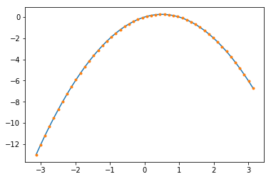

```python
from matplotlib import pyplot as plt  # the tidy way
%matplotlib inline

x = np.linspace(-np.pi, np.pi, 50, endpoint=True)
y = x-x**2

plt.plot(x, y) # line plot
plt.plot(x, y, '.') # dot plot

plt.show()
```

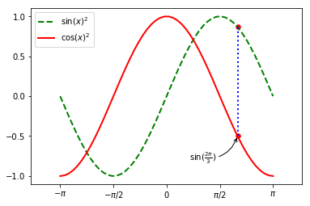

```python
f,g = np.sin, np.cos
y = f(x)
z = g(x)

# customized!
plt.plot(x, y, color="green",
         linewidth=2.0,
         linestyle="--",
         label = r'$\sin(x)^2$') # line plot

plt.plot(x, z, color="red",
         linewidth=2.0,
         linestyle="-",
         label = r'$\cos(x)^2$') # line plot

# set the x and y limits
plt.xlim(-4.0, 4.0)
plt.ylim(-1.1, 1.1)

# change the tick marks
plt.yticks([-1, -1/2, 0,1/2,1])

# chane ticks with labels
plt.xticks([-np.pi, -np.pi/2, 0, np.pi/2, np.pi],
    [r'$-\pi$',r'$-\pi/2$',r'$0$',r'$\pi/2$',r'$\pi$'])

# add a vertical line
t = 2 * np.pi / 3
plt.plot([t, t], [g(t), f(t)],
         color='blue', linewidth=2.0,
         linestyle=":")

# add some points using a scatter plot
plt.scatter([t,t],[f(t),g(t)], 30, color='red')

# add annotation
plt.annotate(r'$\sin(\frac{2\pi}{3})$',
             xy=(t, g(t)), xycoords='data',
             xytext=(-60,-30), textcoords='offset points',
             arrowprops = dict(arrowstyle="->",
                               connectionstyle="arc3,rad=.4"))

# add a legend
plt.legend(loc='upper left')

plt.show()
```

**Remark** the strings of the form `r'stuff'` are called **raw strings**, they exists so that `\` and other special characters are treated as just those characters an not like a LaTeX-style **escape** character.

**Remark for LaTeX users** You can always **annotate** points and mark things on plot, however, I suggest doing all LaTeX labels using **overpic** or **pinlabel** so that your document and image label fonts are the same.

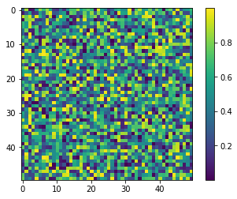

```python
# we can do images too!
image = np.random.rand(50, 50)
plt.imshow(image, interpolation='nearest')
plt.colorbar()
# we can save our work!
# format can be 'svg', 'pdf', 'png', etc
plt.savefig('random_color.eps', format='eps')
plt.show()
```

**Remark** Note that `pyplot.show()` will clear your drawing "canvas", so call `save` before calling `show`. There are also many other ways to save images.

```python
X,Y = np.meshgrid(np.array([0,1]),np.array([2,3]))

print(X)
print(Y)
```

```
[[0 1]
 [0 1]]
[[2 2]
 [3 3]]
```

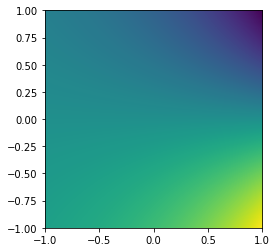

```python
# manually clear canvas
plt.clf()
N = 1000
axis_x = np.linspace(-1,1,N)
axis_y = np.linspace(-1,1,N)

X,Y = np.meshgrid(axis_x,axis_y)

def f(x,y) :
    return (np.exp(x + 1j * y)).imag

image = f(X,Y)

plt.imshow(image, extent=(-1,1,-1,1))
plt.show()
```

**Remark** there are plenty of libraries for plotting complex functions, such as `mpmath`. Above, the color is just a third dimension. Other libraries use color for the imaginary part and brightness for magnitude.

### Subfigures

If you need to arrange several different charts in one place, you can use subfigures. Here is an example.

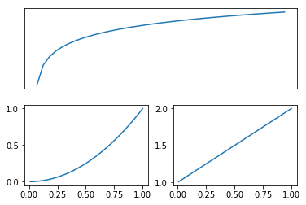

```python
# the 2 indicates take have the height,
# the next 1 indicates take full width
# the last 1 indicates piece to choose
one = plt.subplot(2, 1, 1)
two = plt.subplot(2, 2, 3)
three = plt.subplot(2, 2, 4)
one.xaxis.set_major_locator(plt.NullLocator())
one.yaxis.set_major_locator(plt.NullLocator())

x = np.linspace(0.01,1,40)
one.plot(x,np.log(x))
two.plot(x, x**2)
three.plot(x,1+x)

plt.show()
```

## Other types of plots

`matplotlib` has many other different kinds of plots. You will explore these in the homework.

[figure not shown]

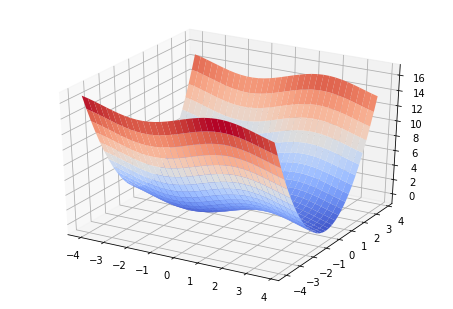

```python
from mpl_toolkits.mplot3d import Axes3D

fig = plt.figure()
ax = Axes3D(fig)
x = np.arange(-4, 4, 0.25)
y = np.arange(-4, 4, 0.25)
X, Y = np.meshgrid(x, y)
Z = (np.sin(X) + Y**2)

ax.plot_surface(X, Y, Z,
                rstride=1, cstride=1,
                cmap='coolwarm', linewidth=0.1)
plt.show()
```

## Plotting (3D) with Mayavi

You can use `matplotlib` tools for 3D plots, but (from what I am told) Mayavi is a much better alternative, however **there might be some difficulties installing it**. I will provide instructions in the homework.

```python
import numpy as np
from mayavi import mlab
```

```python
x, y, z, value = np.random.random((4, 40))
mlab.points3d(x, y, z, value)
mlab.savefig('rand_points.png')
```

[figure not shown]

**Remark** In the lecure notes I am just showing you static images, but in reality, these are interactive.

```python
mlab.clf()  # Clear the figure
t = np.linspace(0, 20, 200)
mlab.plot3d(np.sin(t), np.cos(t), 0.1*t, t)
mlab.savefig('spiral.png')
```

[figure not shown]

```python
mlab.clf()
# mgrid is like mesh grid but in one line
# then 100j means divide in 100 steps insead
# of taking steps of size 100
X, Y = np.mgrid[-10:10:100j, -10:10:100j]
R = np.sqrt(X**2 + Y**2)
Z = np.sin(R)/R
mlab.surf(Z, warp_scale='auto')
mlab.savefig('surface.png')
```

[figure not shown]

## Animations and GIFs

There are several tools for making animations, but the easiest one to use might be `moviepy`. However, this is the first time I am using it, so maybe there are better options.

```python
import numpy as np
import  moviepy.editor as mpy
```

```python
duration= 2 # duration of the animation in seconds (it will loop)

fig_myv = mlab.figure(size=(220,220), bgcolor=(1,1,1))

X, Y = np.mgrid[-2:2:200j, -2:2:200j]

Z = lambda p : np.sinc(X**2 + Y**2) + np.sin(X + p)

def make_frame(t):
    mlab.clf() # clear the figure (to reset the colors)
    mlab.mesh(Y, X, Z(2 * np.pi * t / duration), figure=fig_myv)
    return mlab.screenshot(antialiased=True)

animation = mpy.VideoClip(make_frame, duration=duration)
animation.write_gif("sinc.gif", fps=20)
mlab.close()
```

[figure not shown]

```python
# import the game of life step evolution function
# from homework code
from gof import evolution

board = np.random.randint(2, size=(30,30))
num_frames = 30
frames = []

for _ in range(num_frames) :
    board = evolution(board)
    frame = np.kron((1-board)*255.0, np.ones((10,10)))
    frames.append(frame)

animation = mpy.ImageSequenceClip(frames, fps=2)
animation.write_gif('game_of_life.gif')
```

[figure not shown]